# Week 2, Class 4

Summary Statistics

Sean Westwood

# Today’s Learning Objectives

## By the End of Class You Will:

- Understand central tendency: mean, median, mode
- Know when to use each measure of center
- Calculate measures of spread: range, variance, standard deviation
- Use `group_by()` and `summarise()` for data analysis

# Summary Statistics

## Why Do We Need Summary Statistics?

**The Problem**: Raw data with thousands of observations is overwhelming

**The Solution**: Summary statistics reduce complexity while preserving key information

**Goal**: Describe the “typical” or “central” value in our data

## Congressional Approval Example

Congressional approval helps us understand public trust in political institutions

**Dataset Description**:

- `congress_approval`: Approval rating for Congress (0-100 scale)
- `party_id`: Respondent’s party affiliation (Democrat, Republican, Independent)
- `age`: Respondent’s age
- `education`: Education level (High School, Some College, Bachelor’s, etc.)
- `income_category`: Income bracket ($30k-$60k, etc.)
- `region`: Geographic region (Midwest, South, etc.)

```
# A tibble: 10 × 7
   respondent_id   age education    party_id    income_category region
           <dbl> <dbl> <chr>        <chr>       <chr>           <chr>
 1             1    31 Some College Independent $30k-$60k       Midwest
 2             2    68 Bachelor's   Republican  $30k-$60k       South
 3             3    41 Some College Republican  $30k-$60k       South
 4             4    75 Bachelor's   Democrat    $30k-$60k       South
 5             5    19 Some College Democrat    $60k-$100k      West
 6             6    55 Some College Republican  $30k-$60k       South
 7             7    27 Some College Democrat    $60k-$100k      Midwest
 8             8    49 High School  Republican  Under $30k      West
 9             9    57 Bachelor's   Republican  Under $30k      Midwest
10            10    56 High School  Democrat    Over $100k      South
# ℹ 1 more variable: congress_approval <dbl>
```

## The Mean (Average)

$$\bar{x} = \frac{\sum_{i=1}^{n} x_i}{n}$$

**What this notation means**:

- $\bar{x}$ (x-bar): The sample mean
- $\sum_{i=1}^{n}$: Sum from the first observation (i=1) to the last (i=n)
- $x_i$: Each individual value in our dataset
- $n$: Total number of observations

```r
# Calculate mean approval rating
mean_approval <- mean(approval$congress_approval, na.rm = TRUE)
mean_approval
```

```
[1] 28.70509
```

## The Median (Middle Value)

**Definition**: The value that splits the data in half

```r
# Calculate median approval rating
median_approval <- median(approval$congress_approval, na.rm = TRUE)
median_approval
```

```
[1] 28.50776
```

## The Mode (Most Common Value)

**Definition**: The value that appears most frequently

```r
# Find mode using count
approval %>%
  count(congress_approval, sort = TRUE) %>%
  head(5)
```

```
# A tibble: 5 × 2
  congress_approval     n
              <dbl> <int>
1             0        35
2             0.238     1
3             0.526     1
4             0.808     1
5             0.831     1
```

# Central Tendency

## What is Central Tendency?

**Definition**: Central tendency describes where the “center” or “typical” value of a dataset lies.

**Three main measures**:

1. **Mean** (average): Mathematical center
2. **Median** (middle): Positional center
3. **Mode** (most common): Most frequent value

**Key Insight**: Different measures of central tendency can tell different stories about the same data, especially when distributions are skewed or have outliers

## When Distributions Aren’t Symmetric

**Real data often has:**

- **Outliers**: Extreme values that don’t fit the typical pattern
- **Skewness**: Data stretched more in one direction than the other
- **Multiple modes**: More than one common value

**Why this matters**: Different shapes require different approaches to finding the “typical” value

## Understanding Outliers

**Definition**: Data points that are unusually far from other observations

**Examples in political data**:

- A presidential approval rating of 90% during a crisis
- A candidate spending $500 million in a typical House race
- A voter turnout of 95% in a large precinct

**Impact on measures**:

- **Mean**: Very sensitive to outliers (gets “pulled” toward them)
- **Median**: Resistant to outliers (stays stable)
- **Mode**: Usually unaffected by outliers

## Understanding Skewness

**Left-skewed (negative skew)**:

- Long tail extends toward lower values
- Mean < Median
- Example: Test scores when most students do well

**Right-skewed (positive skew)**:

- Long tail extends toward higher values
- Mean > Median
- Example: Income data (few very wealthy people)

Campaign spending, wealth, and many political variables are typically right-skewed

## Symmetric Distribution

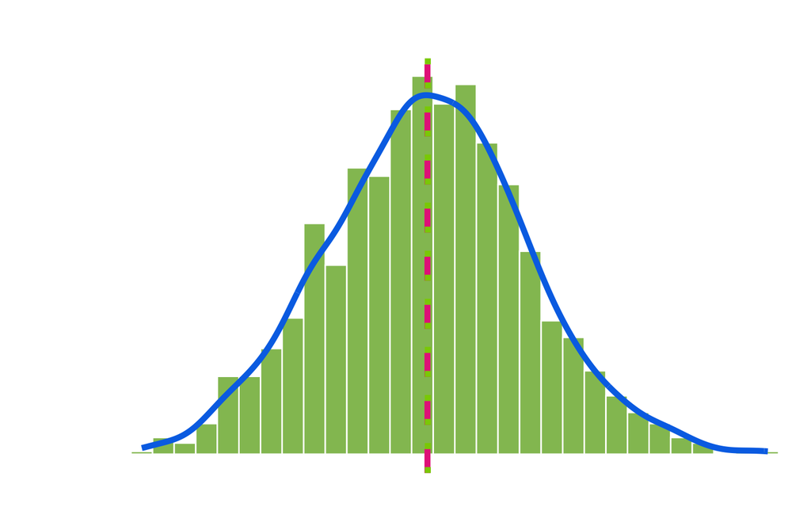

**All three measures are similar**

## Right-Skewed Distribution

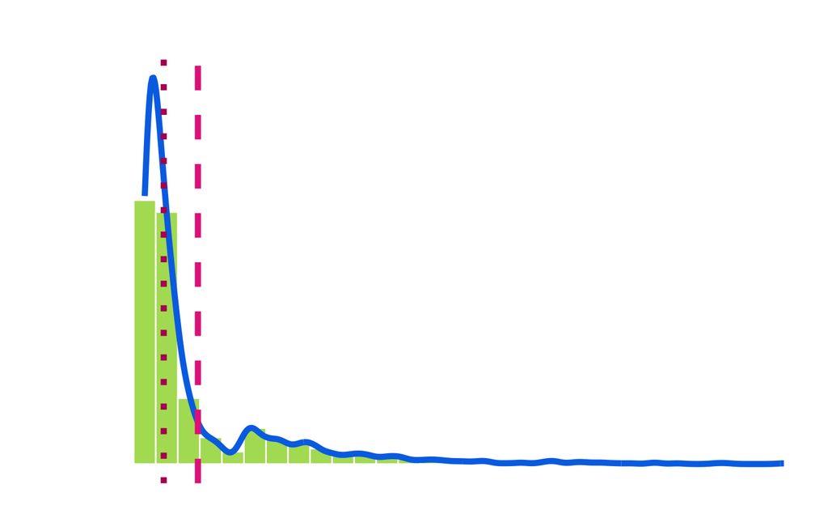

**Mean pulled toward high values**

## Left-Skewed Distribution

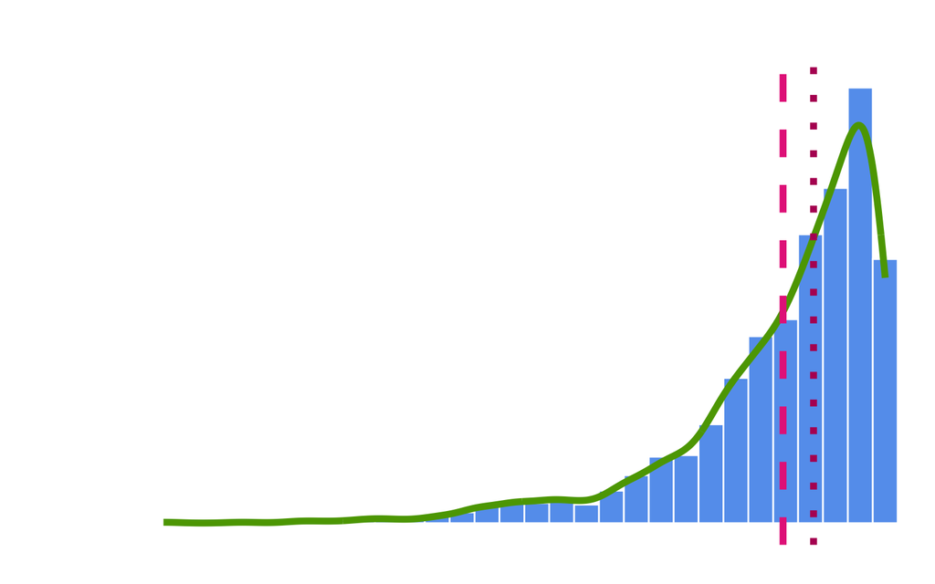

**Mean pulled toward low values**

# Example: Income Distribution

## Why This Matters

```r
# Calculate all three measures
mean_income <- mean(income)
median_income <- median(income)
mode_income <- income[which.max(tabulate(match(income, unique(income))))]

print(paste("Mean:", round(mean_income, 0)))
```

```
[1] "Mean: 83264"
```

```r
print(paste("Median:", round(median_income, 0)))
```

```
[1] "Median: 54176"
```

**Notice**: Mean is much higher than median due to wealthy outliers

# Historical Context: Adolphe Quetelet

## The “Average Man” (1835)

[figure not shown]

**Adolphe Quetelet**: Belgian statistician who pioneered the use of statistics in social science

Wanted to understand the “average man” (l’homme moyen) and devloped anthropetry and BMI

- **Measured** physical characteristics of soldiers
- **Calculated** average height, weight, chest measurements, etc.
- **Identified** Human physical traits follow predictable patterns (distributions)

Unfortuantely, he was a racist and used his work to justify eugenics

# Measures of Spread

## Why Central Tendency Isn’t Enough

Consider two datasets with the same mean:

- **Midterm Dataset A**: 48, 49, 50, 51, 52 (mean = 50)
- **Midterm Dataset B**: 10, 30, 50, 70, 90 (mean = 50)

**Question**: Are these datasets the same?

Means are not enough! We need measures of **spread** or **variability**.

## Range

**Definition**: Difference between maximum and minimum values

```r
# Calculate range for approval ratings
approval %>%
  summarise(
    min_approval = min(congress_approval, na.rm = TRUE),
    max_approval = max(congress_approval, na.rm = TRUE),
    range = max_approval - min_approval
  )
```

```
# A tibble: 1 × 3
  min_approval max_approval range
         <dbl>        <dbl> <dbl>
1            0         75.9  75.9
```

**Limitation**: Sensitive to outliers, ignores distribution shape

## Variance and Standard Deviation

**Variance**:

$$s^2 = \frac{\sum_{i=1}^{n}(x_i - \bar{x})^2}{n-1}$$

**Standard Deviation**:
$$s = \sqrt{s^2}$$

**Understanding the notation:**

- $s^2$ = sample variance (s-squared)
- $s$ = sample standard deviation
- $x_i$ = each individual observation (i = 1, 2, 3, … n)
- $\bar{x}$ = sample mean (x-bar)
- $n$ = sample size

## Understanding Variance and Standard Deviation

**What do they measure?**

- **Variance**: Average of squared distances from the mean
- **Standard Deviation**: Typical distance observations are from the mean
- **Both measure “spread”** - how much data points vary around the center

## Step-by-Step Calculation Example

**Step 1: Find the mean**

**Step 2: Calculate deviations from mean**

| Value | Mean | Deviation $(x_i - \bar{x})$ | Squared Deviation $(x_i - \bar{x})^2$ |
| --- | --- | --- | --- |
| 45 | 50 | -5 | 25 |
| 48 | 50 | -2 | 4 |
| 50 | 50 | 0 | 0 |
| 52 | 50 | 2 | 4 |
| 55 | 50 | 5 | 25 |

**Step 3: Sum the squared deviations**
$$\sum(x_i - \bar{x})^2 = 25 + 4 + 0 + 4 + 25 = 58$$

## Variance and Standard Deviation: With R

```r
# Calculate variance and standard deviation
approval %>%
  summarise(
    variance = var(congress_approval, na.rm = TRUE),
    std_dev = sd(congress_approval, na.rm = TRUE),
    mean = mean(congress_approval, na.rm = TRUE)
  )
```

```
# A tibble: 1 × 3
  variance std_dev  mean
     <dbl>   <dbl> <dbl>
1     183.    13.5  28.7
```

# Data Analysis with summarise() and group_by()

## The `summarise()` Function

**Purpose**: Create summary statistics from your data

**Components of `summarise()`:**

- **Input**: A data frame
- **Output**: A single row with your calculated statistics
- **Functions**: Any function that returns a single value (mean, median, sd, n, etc.)

## Basic `summarise()` Example

```r
# Load congressional data
congress <- read_csv("../../data/HSall_members.csv")

# Single summary of the entire dataset
congress %>%
  summarise(
    total_members = n(),                                    # Count of rows
    avg_ideology = mean(nominate_dim1, na.rm = TRUE),      # Mean
    median_ideology = median(nominate_dim1, na.rm = TRUE), # Median
    spread_ideology = sd(nominate_dim1, na.rm = TRUE),     # Standard deviation
    min_ideology = min(nominate_dim1, na.rm = TRUE),       # Minimum
    max_ideology = max(nominate_dim1, na.rm = TRUE)        # Maximum
  )
```

```
# A tibble: 1 × 6
  total_members avg_ideology median_ideology spread_ideology min_ideology
          <int>        <dbl>           <dbl>           <dbl>        <dbl>
1         51044      0.00727           -0.04           0.377           -1
# ℹ 1 more variable: max_ideology <dbl>
```

**Key insight**: `summarise()` reduces your entire dataset to a single row of summary statistics

## Adding `group_by()` for Subgroup Analysis

But what if we want to compare the mean ideology of Republicans vs. Democrats?

**`group_by()`**: Apply `summarise()` to subgroups instead of the entire dataset

```r
# Same summary, but BY party
congress %>%
  group_by(party_code) %>%
  summarise(
    count = n(),
    avg_nominate_dim1 = mean(nominate_dim1, na.rm = TRUE),
    median_nominate_dim1 = median(nominate_dim1, na.rm = TRUE),
    sd_nominate_dim1 = sd(nominate_dim1, na.rm = TRUE)
  )
```

```
# A tibble: 53 × 5
   party_code count avg_nominate_dim1 median_nominate_dim1 sd_nominate_dim1
   <chr>      <int>             <dbl>                <dbl>            <dbl>
 1 1            847           0.539                0.585              0.242
 2 1060          11           0.0829               0.204              0.207
 3 108            8          -0.0103              -0.002              0.188
 4 1111           1           0.907                0.907             NA
 5 1116           1           0.068                0.068             NA
 6 112           13          -0.039                0.02               0.377
 7 114            9           0.298                0.361              0.141
 8 117            2          -0.00900             -0.00900            0.255
 9 1275         395           0.240                0.286              0.241
10 13          1976          -0.0615              -0.077              0.275
# ℹ 43 more rows
```

## Grouping Multiple Variables

**You can group by multiple variables to create more detailed breakdowns:**

```r
# Summary by party AND chamber
congress %>%
  group_by(party_code, chamber) %>%
  summarise(
    count = n(),
    avg_nominate_dim1 = mean(nominate_dim1, na.rm = TRUE),
    .groups = "drop"  # Removes grouping after summarise
  )
```

```
# A tibble: 93 × 4
   party_code chamber   count avg_nominate_dim1
   <chr>      <chr>     <int>             <dbl>
 1 1          House       648            0.521
 2 1          President     3          NaN
 3 1          Senate      196            0.598
 4 1060       House         4           -0.177
 5 1060       Senate        7            0.231
 6 108        House         8           -0.0103
 7 1111       Senate        1            0.907
 8 1116       House         1            0.068
 9 112        House        10           -0.200
10 112        Senate        3            0.499
# ℹ 83 more rows
```

**Note**: `.groups = "drop"` removes grouping after `summarise()` to avoid unexpected behavior

## Comprehensive Statistical Summaries

**Create complete statistical profiles for each group:**

```r
# Complete statistical summary by party
congress %>%
  group_by(party_code) %>%
  summarise(
    count = n(),                                        # Sample size
    mean_ideology = mean(nominate_dim1, na.rm = TRUE), # Central tendency
    median_ideology = median(nominate_dim1, na.rm = TRUE),
    min_ideology = min(nominate_dim1, na.rm = TRUE),   # Range
    max_ideology = max(nominate_dim1, na.rm = TRUE),
    std_dev = sd(nominate_dim1, na.rm = TRUE),         # Spread
    .groups = "drop"
  ) %>%
  mutate(across(where(is.numeric), round, 3))  # Round for readability
```

```
# A tibble: 53 × 7
   party_code count mean_ideology median_ideology min_ideology max_ideology
   <chr>      <dbl>         <dbl>           <dbl>        <dbl>        <dbl>
 1 1            847         0.539           0.585       -0.921        0.998
 2 1060          11         0.083           0.204       -0.177        0.252
 3 108            8        -0.01           -0.002       -0.261        0.232
 4 1111           1         0.907           0.907        0.907        0.907
 5 1116           1         0.068           0.068        0.068        0.068
 6 112           13        -0.039           0.02        -0.559        0.499
 7 114            9         0.298           0.361        0.011        0.406
 8 117            2        -0.009          -0.009       -0.189        0.171
 9 1275         395         0.24            0.286       -0.538        0.682
10 13          1976        -0.061          -0.077       -0.996        0.919
# ℹ 43 more rows
# ℹ 1 more variable: std_dev <dbl>
```

# The count() Function

## Counting Observations

```r
# Count with conditions
congress %>%
  filter(nominate_dim1 > 0.6) %>%
  count(party_code, sort = TRUE)
```

```
# A tibble: 16 × 2
   party_code     n
   <chr>      <int>
 1 Republican  1347
 2 1            395
 3 5000          72
 4 13            29
 5 29            24
 6 1275          20
 7 22            17
 8 8888          13
 9 7777           5
10 Democrat       5
11 300            3
12 8000           2
13 1111           1
14 1346           1
15 26             1
16 331            1
```

# AI Integration for Statistical Analysis

## Effective Prompts for Summary Statistics

**For choosing the right measure:**

> “I have presidential approval rating data that might have outliers. Should I use mean or median to summarize it? Please explain the difference and provide R code for both.”

**For grouping analysis:**

> “Help me write tidyverse code to calculate mean, median, and standard deviation of vote_share, grouped by party_code and state_abbrev. Explain what you did. My dataframe is called congress and it looks like this: <insert glimpse()>”

## Interpreting Results with AI

**For understanding patterns:**

> “I calculated that Republican candidates have a mean vote share of 0.52 and Democrats have 0.48, with standard deviations of 0.15 and 0.18 respectively. What does this tell me about voting patterns?”

**AI helps you understand:**

- What the numbers mean in context
- Whether differences are meaningful
- What questions to ask next

# Common Mistakes and Solutions

## Forgetting to Handle Missing Values

```r
# This might give NA if there are missing values
test_data <- c(1, 2, 3, NA, 5)
mean(test_data)  # Returns NA
```

```
[1] NA
```

```r
# Solution: use na.rm = TRUE
mean(test_data, na.rm = TRUE)  # Returns 2.75
```

```
[1] 2.75
```

## Choosing the Wrong Measure

**Use Mean When:**

- Data is roughly symmetric
- You want to include all values
- Making predictions

**Use Median When:**

- Data has outliers
- Data is skewed
- Describing “typical” experience

# Best Practices

## Report Multiple Measures

```r
# Comprehensive summary
approval %>%
  summarise(
    n = n(),
    mean = mean(congress_approval, na.rm = TRUE),
    median = median(congress_approval, na.rm = TRUE),
    sd = sd(congress_approval, na.rm = TRUE),
    min = min(congress_approval, na.rm = TRUE),
    max = max(congress_approval, na.rm = TRUE)
  ) %>%
  mutate(across(where(is.numeric), round, 2))
```

```
# A tibble: 1 × 6
      n  mean median    sd   min   max
  <dbl> <dbl>  <dbl> <dbl> <dbl> <dbl>
1  2000  28.7   28.5  13.5     0  75.9
```

## Think About Context

**Numbers without context are meaningless**

- Is a 5-point difference in approval ratings large?
- What’s a typical range for vote shares?
- How do current values compare to historical patterns?

# Looking Ahead

## Next Week Preview

**Research Designs**:

- Experimental vs observational studies
- Natural experiments
- The fundamental problem of causal inference
- When can we make causal claims?

## Key Concepts to Remember

- **Mean** includes all values but sensitive to outliers
- **Median** resistant to outliers, good for skewed data
- **Standard deviation** measures spread around the mean
- **group_by() + summarise()** powerful for comparing groups
- **Context matters** - interpret statistics in real-world terms

# Questions?

**Key takeaway**: Summary statistics are tools for understanding data patterns. Choose the right tool for your data and always interpret results in context.

Next class: We’ll learn about different research designs and when we can make causal claims from data.